# 2.4 Exercises

2. What is the *range* of each quantitative predictor? You can answer this using the **range()** function.

```r
quantFields = c('mpg', 'displacement', 'horsepower', 'weight', 'acceleration')
for (field in quantFields){
  x = range(Auto[[field]])
  print(sprintf('%s range: %.0f - %.0f', field, x[1], x[2]))
}
```

```
## [1] "mpg range: 9 - 47"
## [1] "displacement range: 68 - 455"
## [1] "horsepower range: 46 - 230"
## [1] "weight range: 1613 - 5140"
## [1] "acceleration range: 8 - 25"
```

3. What is the mean and standard deviation of each quantitative predictor?

```r
# Note that we already have these values from the summary produced above, but I assume the author
# is looking for the mean and sd functions to be used here
for (field in quantFields){
  data = Auto[[field]]
  print(sprintf('%s %s: %.2f', field, c('mean', 'std'), c(mean(data), sd(data))))
}
```

```
## [1] "mpg mean: 23.45" "mpg std: 7.81"
## [1] "displacement mean: 194.41" "displacement std: 104.64"
## [1] "horsepower mean: 104.47" "horsepower std: 38.49"
## [1] "weight mean: 2977.58" "weight std: 849.40"
## [1] "acceleration mean: 15.54" "acceleration std: 2.76"
```

4. Now remove the 10th through 85th observations. What is the range, mean, and standard deviation of each predictor in the subset of the data that remains?

```r
# Note: you can't use the 10:85 shorthand combined with negative indexing to drop rows; you have to write out the call to the seq() function
reducedAuto = Auto[-seq(10,85),]
for (field in quantFields){
  data = reducedAuto[[field]]
  print(sprintf('%s %s: %.2f', field, c('mean', 'std'), c(mean(data), sd(data))))
}
```

```
## [1] "mpg mean: 24.40" "mpg std: 7.87"
## [1] "displacement mean: 187.24" "displacement std: 99.68"
## [1] "horsepower mean: 100.72" "horsepower std: 35.71"
## [1] "weight mean: 2935.97" "weight std: 811.30"
## [1] "acceleration mean: 15.73" "acceleration std: 2.69"
```

5. Using the full data set, investigate the predictors graphically, using scatterplots or other tools of your choice. Create some plots highlighting the relationships among the predictors. Comment on your findings.

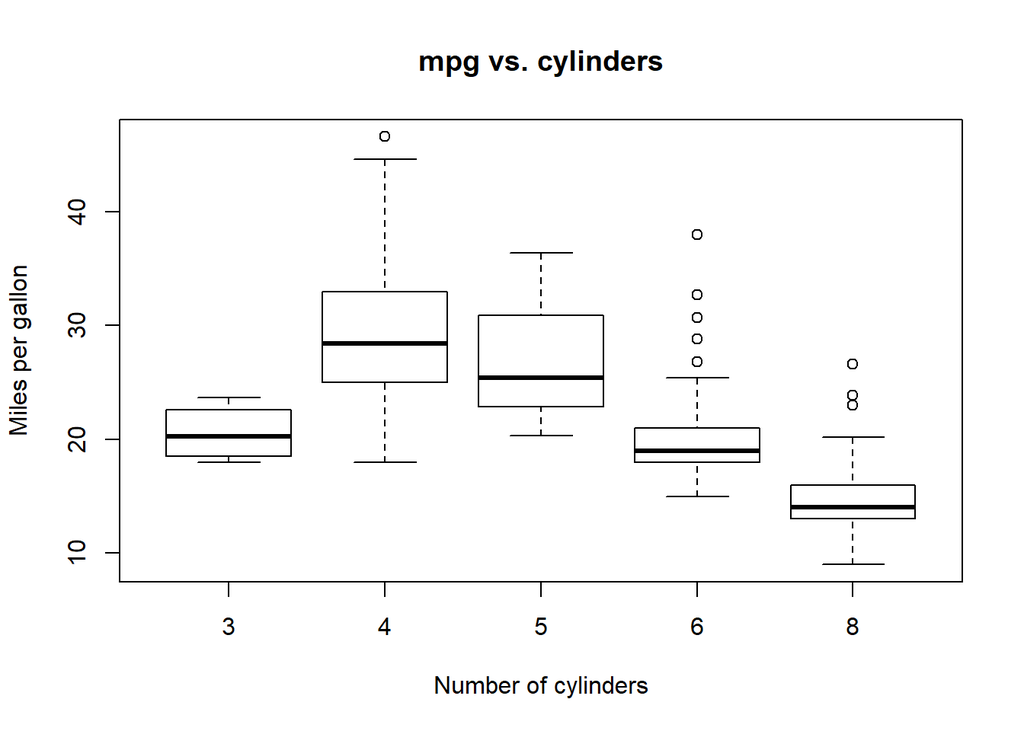

```r
cylinders = as.factor(Auto$cylinders)
plot(x=cylinders, y=Auto$mpg, xlab='Number of cylinders', ylab='Miles per gallon', main='mpg vs. cylinders')
```

*From this data, it appears that 4 cylinders is ideal for maximizing the gas mileage of a car. Additional cylinders beyond 4 begin to drastically decrease the fuel efficiency of a car.*

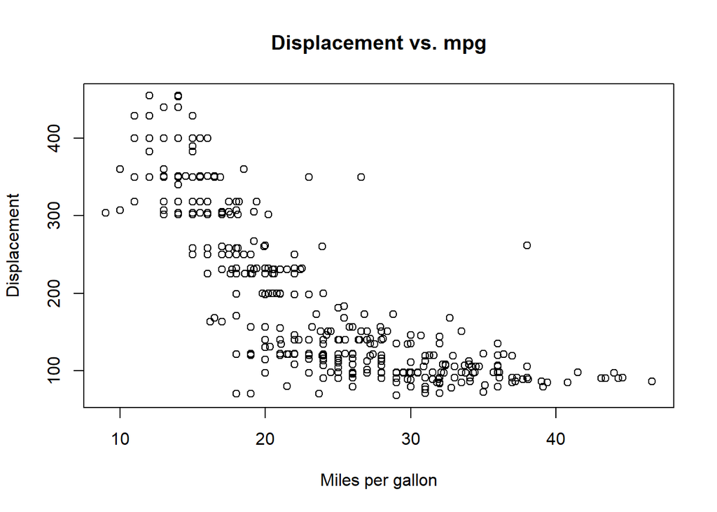

```r
plot(x=Auto$mpg, y=Auto$displacement, xlab='Miles per gallon', ylab='Displacement', main='Displacement vs. mpg')
```

*Miles per gallon seems to increase exponentially as displacement decreases.*

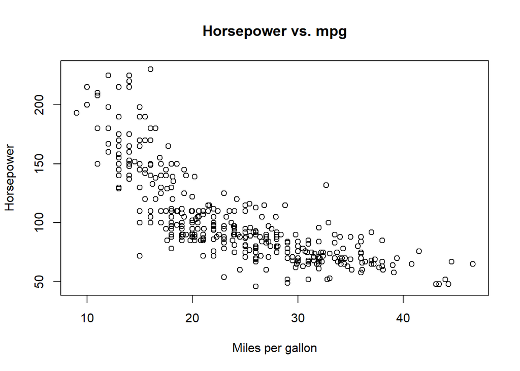

```r
plot(x=Auto$mpg, y=Auto$horsepower, xlab='Miles per gallon', ylab='Horsepower', main='Horsepower vs. mpg')
```

*Horsepower seems to share a similar relationship to mpg as displacement does. (i.e. mpg tends to increase exponentially as horsepower decreases.)*

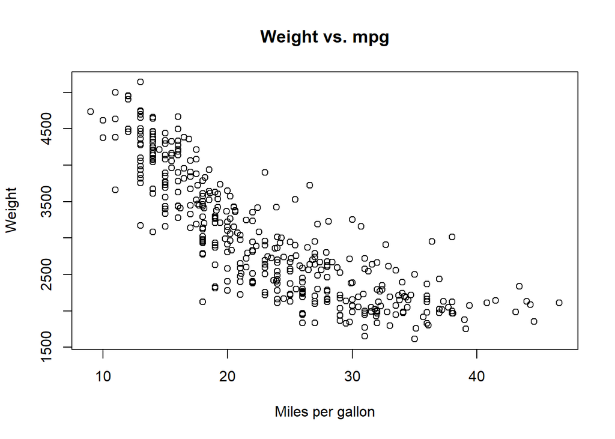

```r
plot(x=Auto$mpg, y=Auto$weight, xlab='Miles per gallon', ylab='Weight', main='Weight vs. mpg')
```

*Not surprisingly, fuel efficiency decreases exponentially as the weight of the car increases.*

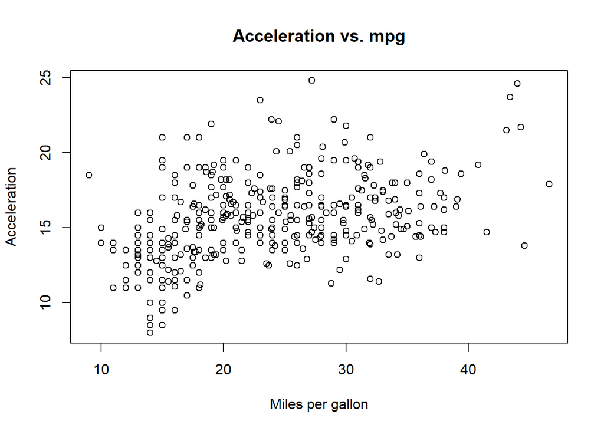

```r
plot(x=Auto$mpg, y=Auto$acceleration, xlab='Miles per gallon', ylab='Acceleration', main='Acceleration vs. mpg')
```

```r
cor(x=Auto$mpg, y=Auto$acceleration)
```

```
## [1] 0.4233285
```

*Acceleration is not strongly correlated to the gas mileage of a car. Although there is not a definitive relationship here, the mpg does tend to increase as acceleration also increases.*

[figure not shown]

```r
year_mpg = aggregate(Auto[,1], list(year=Auto$year), mean)
plot(x=year_mpg$year, y=year_mpg$mpg, xlab='Year', ylab='Average miles per gallon', main='Average mpg vs. year')
```

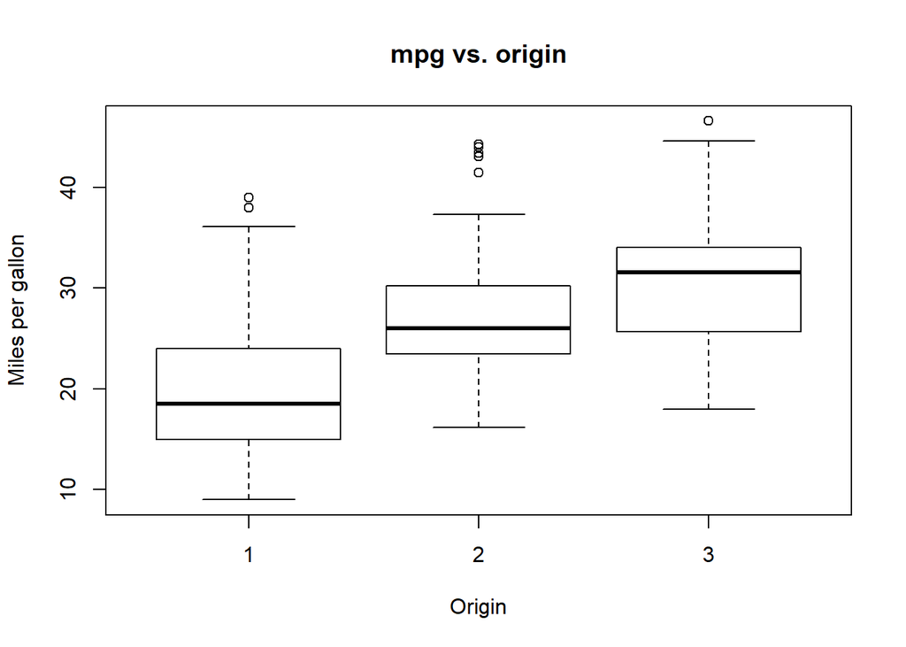

```r
origin = as.factor(Auto$origin)
plot(x=origin, y=Auto$mpg, xlab='Origin', ylab='Miles per gallon', main='mpg vs. origin')
```

*I don’t understand what origin is supposed to be, but fuel efficiency seems to increase as origin goes from 1 to 2 to 3.*

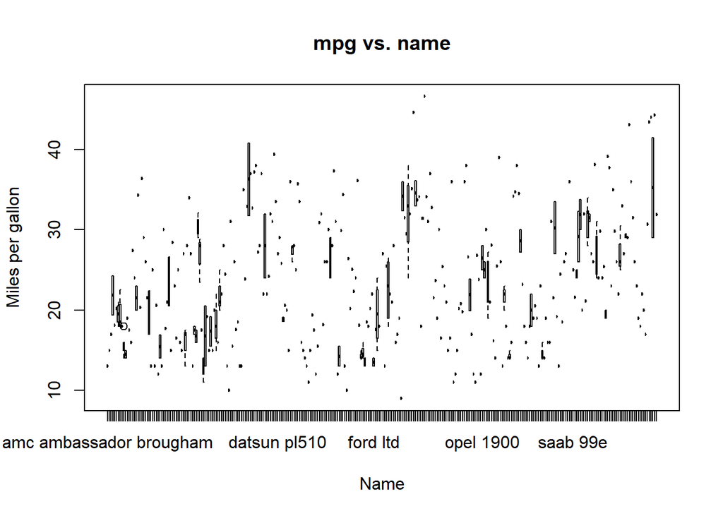

```r
plot(x=Auto$name, y=Auto$mpg, xlab='Name', ylab='Miles per gallon', main='mpg vs. name')
```

*There are too many names to properly sort through them all, but some brands seem to be performing much better than others in terms of fuel efficiency.* (f) Suppose that we wish to predict gas mileage (**mpg**) on the basis of the other variables. Do your plots suggest that any of the other variables might be useful in predicting **mpg**? Justify your answer. *From the above plots, you can see that the number of cylinders, displacement, horsepower, weight, year, and origin of a car are all useful predictors for determining that cars mpg.*